# Lecture 17 - The central limit theorem

Joshua Loftus

#### Announcements

- Homework 6 will be posted soon, class survey as well
- Today: Central limit theorem, more `R` experiments
- Optional additional reading:
- Proofs of the CLT (requires calculus): [here](http://www.cs.toronto.edu/~yuvalf/CLT.pdf)

#### Means of i.i.d. samples

- We are still considering the mean $\bar X_n$ of **i.i.d. random variables** $X_1, \ldots, X_n$.
- **Notation**: we are still emphasizing that the sample mean depends on the sample size by the subscript $n$
- Let $\mu = E[X_i]$, and $\sigma^2 = \text{Var}(X_i)$, so $E[\bar X_n] = \mu$ and $\text{Var}(\bar X_n) = \sigma^2/n$.
- Recall this from the lecture about the sampling distribution of the mean:

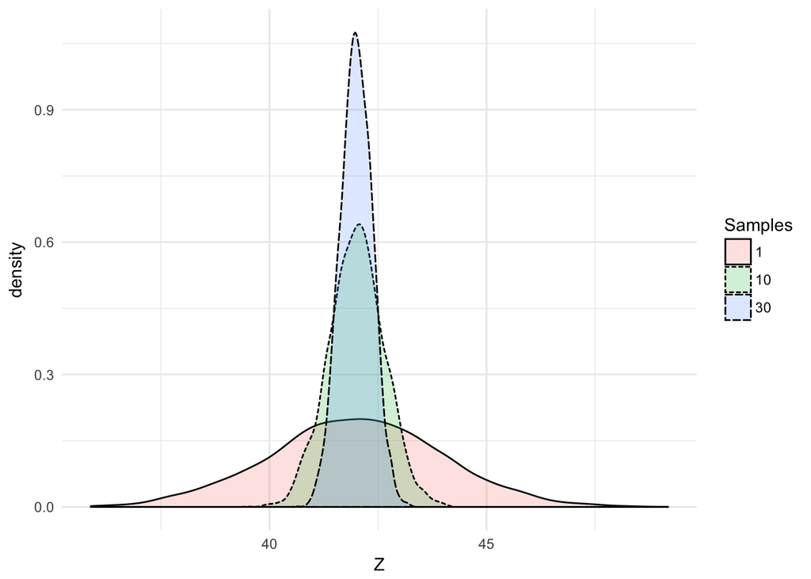

```r
true_mu <- 42
Zbar <- function(n) mean(rnorm(n, mean = true_mu, sd = 2))
df <- data.frame(Z = c(rnorm(5000, mean = true_mu, sd = 2),
                       replicate(5000, Zbar(10)),
                       replicate(5000, Zbar(30))),
                 Samples = factor(c(rep(1, 5000), rep(10, 5000), rep(30, 5000))))
ggplot(df, aes(Z, fill = Samples, linetype = Samples)) + geom_density(alpha = .2) + theme_minimal()
```

- **Square root convergence**: the dispersion of the sampling distribution of the mean decreases like $1/\sqrt{n}$
- One way to see this is with Chebyshev’s inequality applied to the mean:
  $$P\left(\left|\bar X_n - \mu\right| > k \frac{\sigma}{\sqrt{n}} \right) \leq 1/k^2$$
- The (strong) law of large numbers says $\bar X_n \to \mu$ as $n \to \infty$, the errors get smaller and smaller.
- But what happens if we zoom in fast enough to keep the errors from going to zero? i.e. scale by $\sqrt{n}$
- Does $\sqrt{n}(\bar X_n - \mu)$ converge to a limit?

#### Central limit theorem

- If we blow up the errors, increasing the dispersion, by a factor of $\sqrt{n}$, then $\bar X_n$ no longer converges to a specific number. Multiplying the errors by $\sqrt{n}$ is enough to make them large enough that the variability never goes to 0.
- Instead of the limit being a specific number ($\mu$), the limit is now a *random variable*.
- The **central limit theorem** says, for any constants $a < b$ (possibly infinite),
  $$P\left( a \leq \sqrt{n}\left( \bar X_n - \mu \right) \leq b \right) \to P(a \leq Z \leq b) \quad \text{where} \quad Z \sim N(0, \sigma^2)$$
- Notice that we did *not* assume the $X_i$ are normal!
- This is sometimes referred to as a “universality” theorem because it says $Z$ is a universal distribution for the *error of the mean*.
- The $X_i$ can even be discrete, like Binomial, but this limit will still be the continuous $Z$.
- Note that the *variance* of $Z$ is $\text{Var}(X_i) = \sigma^2$.

#### How to think about the central limit theorem

- For large enough $n$, $\bar X_n \sim N(\mu, \sigma^2/n)$ (approximately)
- But for any real sample with $n$ observations, $\bar x_n$ is just a specific number, so $\sqrt{n}(\bar x_n - \mu)$ is also just one number.
- It is unknown, because $\mu$ is unknown.
- Thought experiment: imagine collecting another sample with the same size and computing $\bar x_n$ again. Plot it.
- After repeating many times, the histogram of the plotted $\bar x_n$ values should be centered at $\mu$, have variance $\sigma^2/n$, and have the shape of a normal distribution.
- For large enough $n$, the **sampling distribution of the mean** is **approximately normal**

#### Example: Exponential distribution

Shape of the underlying random variable distribution is *not* normal:

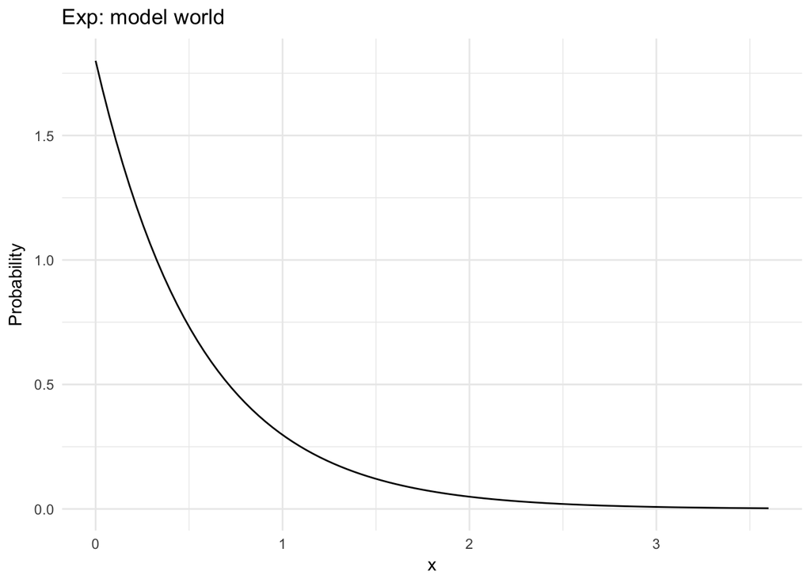

```r
# True parameters, try changing them
rate = 1.8
# Don't change this
true_mu = 1/rate
true_var = 1/rate^2
X <- seq(from = 0, to = 2*rate, length.out = 100)
ggplot(data.frame(x=X, Probability=dexp(X, rate)), aes(x, Probability)) +
  geom_line() + theme_minimal() + ggtitle("Exp: model world")
```

Plot the sampling distribution of the mean, as the sample size increases

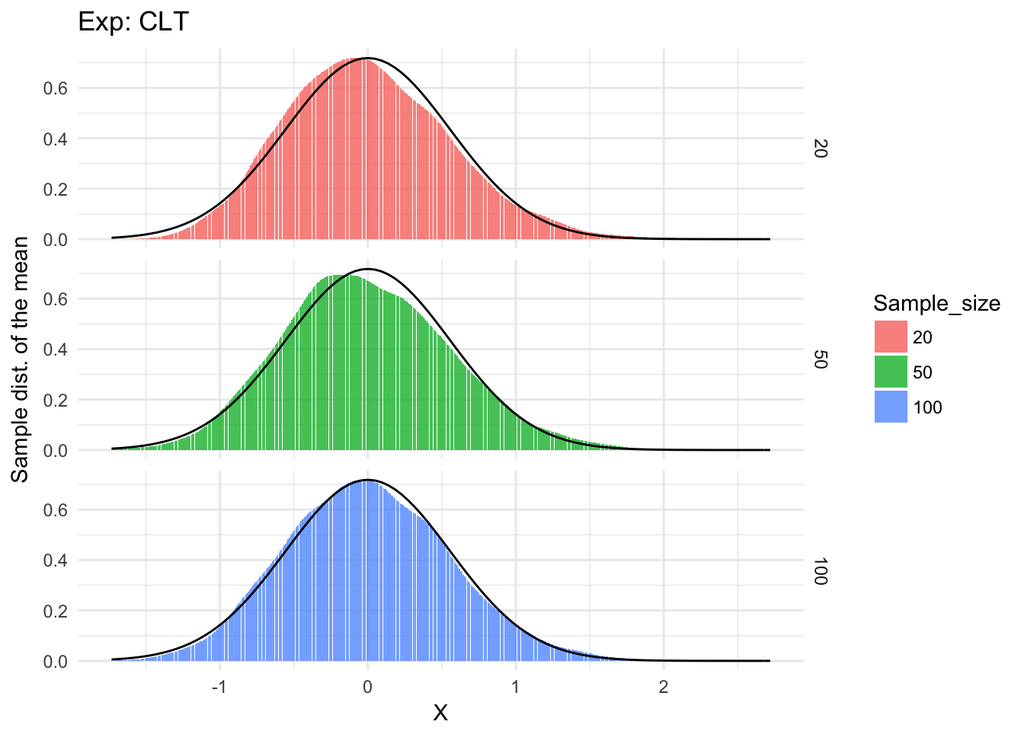

```r
Xbar <- function(n) sqrt(n) * (mean(rexp(n, rate)) - true_mu)
df <- data.frame(X = c(replicate(5000, Xbar(20)),
                       replicate(5000, Xbar(50)),
                       replicate(5000, Xbar(100))),
                 Sample_size = factor(c(rep(20, 5000),
                                        rep(50, 5000),
                                        rep(100, 5000))))
ggplot(df, aes(X, fill = Sample_size)) +
  geom_bar(alpha = .8, stat = "density", position = "identity") +
  theme_minimal() + ylab("Sample dist. of the mean") + theme_minimal() +
  stat_function(fun = dnorm, args = list(sd = sqrt(true_var))) +
  facet_grid(Sample_size~.) + ggtitle("Exp: CLT")
```

#### R markdown lab

- Download the `CLTlab.Rmd` file from the course page and open it in Rstudio.